# Introduction

```r
#install.packages("ISLR","tidyverse","haven","readxl")
library(ISLR)
library(tidyverse)
library(haven)
library(readxl)
library(here)
```

# Data types

1. **Run the following code in `R` and inspect their data types using the `class()` function. Try to guess beforehand what their types will be!**

```r
object_1 <- 1:5
object_2 <- 1L:5L
object_3 <- "-123.456"
object_4 <- as.numeric(object_2)
object_5 <- letters[object_1]
object_6 <- as.factor(rep(object_5, 2))
object_7 <- c(1, 2, 3, "4", "5", "6")

class(object_1)
```

```
## [1] "integer"
```

```r
class(object_2)
```

```
## [1] "integer"
```

```r
class(object_3)
```

```
## [1] "character"
```

```r
class(object_4)
```

```
## [1] "numeric"
```

```r
class(object_5)
```

```
## [1] "character"
```

```r
class(object_6)
```

```
## [1] "factor"
```

```r
class(object_7)
```

```
## [1] "character"
```

2. **Convert `object_7` back to a vector of numbers using the `as.numeric()` function**

```r
object_7<-as.numeric(object_7)
object_7
```

```
## [1] 1 2 3 4 5 6
```

```r
class(object_7)
```

```
## [1] "numeric"
```

# Lists and data frames

3. **Make a list called `objects` containing object 1 to 7 using the `list()` function.**

```r
objects <- list(object_1, object_2, object_3, object_4, object_5, object_6,
                object_7)
```

4. **Make a data frame out of `object_1`, `object_2`, and `object_5` using the `data.frame()` function**

```r
dat <- data.frame(Var1 = object_1, Var2 = object_2, Var3 = object_5)
dat
```

```
##   Var1 Var2 Var3
## 1    1    1    a
## 2    2    2    b
## 3    3    3    c
## 4    4    4    d
## 5    5    5    e
```

```r
#also can be done with tibble
data<-tibble(Var1 = object_1, Var2 = object_2, Var3 = object_5)
data
```

```
## # A tibble: 5 x 3
##    Var1  Var2 Var3
##   <int> <int> <chr>
## 1     1     1 a
## 2     2     2 b
## 3     3     3 c
## 4     4     4 d
## 5     5     5 e
```

5. **Useful functions for determining the size of a data frame are `ncol()` and `nrow()`. Try them out!**

```r
ncol(dat)
```

```
## [1] 3
```

```r
nrow(dat)
```

```
## [1] 5
```

# Loading, viewing, and summarising data

6. **Use the function `read_csv()` to import the file “data/googleplaystore.csv” and store it in a variable called `apps`.**

```r
apps <- read_csv("data/googleplaystore.csv")
```

7. **Did any column get a variable type you did not expect?**

```r
# size, price could be number while they are of the type character
spec(apps)
```

8. **Use the function `head()` to look at the first few rows of the `apps` dataset**

```r
head(apps)
```

```
## # A tibble: 6 x 13
##   App    Categ~1 Rating Reviews Size  Insta~2 Type  Price Conte~3 Genres Last ~4
##   <chr>  <chr>    <dbl>   <dbl> <chr> <chr>   <chr> <chr> <chr>   <chr>  <chr>
## 1 Photo~ ART_AN~    4.1     159 19M   10,000+ Free  0     Everyo~ Art &~ Januar~
## 2 Color~ ART_AN~    3.9     967 14M   500,00~ Free  0     Everyo~ Art &~ Januar~
## 3 U Lau~ ART_AN~    4.7   87510 8.7M  5,000,~ Free  0     Everyo~ Art &~ August~
## 4 Sketc~ ART_AN~    4.5  215644 25M   50,000~ Free  0     Teen    Art &~ June 8~
## 5 Pixel~ ART_AN~    4.3     967 2.8M  100,00~ Free  0     Everyo~ Art &~ June 2~
## 6 Paper~ ART_AN~    4.4     167 5.6M  50,000+ Free  0     Everyo~ Art &~ March ~
## # ... with 2 more variables: `Current Ver` <chr>, `Android Ver` <chr>, and
## #   abbreviated variable names 1: Category, 2: Installs, 3: `Content Rating`,
## #   4: `Last Updated`
```

9. **Repeat steps 5, 6, and 7 but now for “data/students.xlsx” (NB: You’ll need a function from the package `readxl`). Also try out the function `tail()` and `View()` (with a capital V).**

```r
#student_number could possibly be an integer instead of the double
students <- read_xlsx("data/students.xlsx")
head(students)
```

```
## # A tibble: 6 x 3
##   student_number grade programme
##            <dbl> <dbl> <chr>
## 1        5117250  6.54 A
## 2        6562582  7.57 A
## 3        6000241  6.08 B
## 4        4862862  7.71 A
## 5        6561723  6.57 B
## 6        5625916  7.90 B
```

```r
tail(students)
```

```
## # A tibble: 6 x 3
##   student_number grade programme
##            <dbl> <dbl> <chr>
## 1        5062746  7.43 B
## 2        6560954  7.04 B
## 3        6120285  6.71 A
## 4        6553913  8.24 A
## 5        4181101  5.62 B
## 6        4639846  4.84 A
```

10. **Create a summary of the three columns in the students dataset using the `summary()` function. What is the range of the grades achieved by the students?**

```r
summary(students)
```

```
##  student_number        grade        programme
##  Min.   :4011659   Min.   :4.844   Length:37
##  1st Qu.:4862862   1st Qu.:6.390   Class :character
##  Median :6000241   Median :7.151   Mode  :character
##  Mean   :5686729   Mean   :6.991
##  3rd Qu.:6553913   3rd Qu.:7.573
##  Max.   :6997130   Max.   :9.291
```

# Data transformation with `dplyr` verbs

11. **Look at the help pages for `filter()` (especially the examples) and show the students with a grade lower than 5.5**

```r
filter(students, grade < 5.5)
```

```
## # A tibble: 3 x 3
##   student_number grade programme
##            <dbl> <dbl> <chr>
## 1        6114656  5.16 A
## 2        5265402  5.49 B
## 3        4639846  4.84 A
```

12. **Show only the students with a grade higher than 8 from programme A**

```r
filter(students, grade > 8, programme == "A")
```

```
## # A tibble: 5 x 3
##   student_number grade programme
##            <dbl> <dbl> <chr>
## 1        6352581  8.09 A
## 2        6165611  8.02 A
## 3        4133949  8.40 A
## 4        4011659  8.94 A
## 5        6553913  8.24 A
```

### Arrange

13. **Sort the students dataset such that the students from programme A are on top of the data frame and within the programmes the highest grades come first.**

```r
arrange(students,programme,-grade)
```

```
## # A tibble: 37 x 3
##    student_number grade programme
##             <dbl> <dbl> <chr>
##  1        4011659  8.94 A
##  2        4133949  8.40 A
##  3        6553913  8.24 A
##  4        6352581  8.09 A
##  5        6165611  8.02 A
##  6        6997130  7.75 A
##  7        4862862  7.71 A
##  8        6562582  7.57 A
##  9        4483974  7.46 A
## 10        5128923  7.26 A
## # ... with 27 more rows
```

### Select

14. **Show only the `student_number` and `programme` columns from the students dataset**

```r
select(students, student_number,programme)
```

```
## # A tibble: 37 x 2
##    student_number programme
##             <dbl> <chr>
##  1        5117250 A
##  2        6562582 A
##  3        6000241 B
##  4        4862862 A
##  5        6561723 B
##  6        5625916 B
##  7        4096023 A
##  8        6114656 A
##  9        5265402 B
## 10        5977188 B
## # ... with 27 more rows
```

### Mutate

With `mutate()` you can compute new columns and transform existing columns as functions of the columns in your dataset. For example, we may create a new logical column in the students dataset to indicate whether a student has passed or failed:

```r
students <- mutate(students, pass = grade > 5.5)
students
```

```
## # A tibble: 37 x 4
##    student_number grade programme pass
##             <dbl> <dbl> <chr>     <lgl>
##  1        5117250  6.54 A         TRUE
##  2        6562582  7.57 A         TRUE
##  3        6000241  6.08 B         TRUE
##  4        4862862  7.71 A         TRUE
##  5        6561723  6.57 B         TRUE
##  6        5625916  7.90 B         TRUE
##  7        4096023  5.92 A         TRUE
##  8        6114656  5.16 A         FALSE
##  9        5265402  5.49 B         FALSE
## 10        5977188  7.26 B         TRUE
## # ... with 27 more rows
```

Now, the students dataset has an extra column named “pass”.

You can also transform existing columns with the `mutate()` function. For example, we may want to transform the programme column to an actual programme name according to this table:

| Code | Name |
| --- | --- |
| A | Science |
| B | Social Science |

15. **Use `mutate()` and `recode()` to change the codes in the programme column of the students dataset to their names. Store the result in a variable called `students_recoded`**

```r
students_recoded <- mutate(students,
  programme = recode(programme, "A" = "Science", "B" = "Social Science")
)
students_recoded
```

```
## # A tibble: 37 x 4
##    student_number grade programme      pass
##             <dbl> <dbl> <chr>          <lgl>
##  1        5117250  6.54 Science        TRUE
##  2        6562582  7.57 Science        TRUE
##  3        6000241  6.08 Social Science TRUE
##  4        4862862  7.71 Science        TRUE
##  5        6561723  6.57 Social Science TRUE
##  6        5625916  7.90 Social Science TRUE
##  7        4096023  5.92 Science        TRUE
##  8        6114656  5.16 Science        FALSE
##  9        5265402  5.49 Social Science FALSE
## 10        5977188  7.26 Social Science TRUE
## # ... with 27 more rows
```

# Data processing pipelines

```r
students_dataset <-
  read_xlsx("data/students.xlsx") %>%
  mutate(prog = recode(programme, "A" = "Science", "B" = "Social Science")) %>%
  filter(grade > 5.5) %>%
  arrange(programme, -grade) %>%
  select(student_number, prog, grade)

students_dataset
```

```
## # A tibble: 34 x 3
##    student_number prog    grade
##             <dbl> <chr>   <dbl>
##  1        4011659 Science  8.94
##  2        4133949 Science  8.40
##  3        6553913 Science  8.24
##  4        6352581 Science  8.09
##  5        6165611 Science  8.02
##  6        6997130 Science  7.75
##  7        4862862 Science  7.71
##  8        6562582 Science  7.57
##  9        4483974 Science  7.46
## 10        5128923 Science  7.26
## # ... with 24 more rows
```

16. **Create a data processing pipeline that (a) loads the apps dataset, (b) parses the number of installs as ‘Downloads’ variable using `mutate` and `parse_number()`, (c) shows only apps with more than 500 000 000 downloads, (d) orders them by rating (best on top), and (e) shows only the relevant columns (you can choose which are relevant, but select at least the `Rating` and `Category` variables). Save the result under the name `popular_apps`.**

```r
popular_apps <-  read_csv("data/googleplaystore.csv") %>%
  mutate(Downloads=parse_number(Installs,na = c("", "NA"))) %>%
  filter(Downloads>5e8) %>%
  arrange(-Rating) %>%
  select(Rating, Category,Downloads) %>% distinct( .keep_all = TRUE)
popular_apps
```

```
## # A tibble: 19 x 3
##    Rating Category             Downloads
##     <dbl> <chr>                    <dbl>
##  1    4.5 GAME                1000000000
##  2    4.5 SOCIAL              1000000000
##  3    4.5 PHOTOGRAPHY         1000000000
##  4    4.4 COMMUNICATION       1000000000
##  5    4.4 TOOLS               1000000000
##  6    4.4 PRODUCTIVITY        1000000000
##  7    4.3 COMMUNICATION       1000000000
##  8    4.3 ENTERTAINMENT       1000000000
##  9    4.3 TRAVEL_AND_LOCAL    1000000000
## 10    4.3 VIDEO_PLAYERS       1000000000
## 11    4.3 FAMILY              1000000000
## 12    4.2 SOCIAL              1000000000
## 13    4.2 TRAVEL_AND_LOCAL    1000000000
## 14    4.1 COMMUNICATION       1000000000
## 15    4.1 SOCIAL              1000000000
## 16    4   COMMUNICATION       1000000000
## 17    3.9 BOOKS_AND_REFERENCE 1000000000
## 18    3.9 NEWS_AND_MAGAZINES  1000000000
## 19    3.7 VIDEO_PLAYERS       1000000000
```

# Grouping and summarisation

```r
students_dataset %>%
  summarise(
    mean = mean(grade),
    variance = var(grade),
    min = min(grade),
    max = max(grade)
  )
```

```
## # A tibble: 1 x 4
##    mean variance   min   max
##   <dbl>    <dbl> <dbl> <dbl>
## 1  7.15    0.817  5.53  9.29
```

17. **Show the median, minimum, and maximum for the popular apps dataset you made in the previous assignment.**

```r
popular_apps %>%
  summarise(
    med = median(Rating),
    min = min(Rating),
    max = max(Rating)
  )
```

```
## # A tibble: 1 x 3
##     med   min   max
##   <dbl> <dbl> <dbl>
## 1   4.3   3.7   4.5
```

The `summarise()` function works with any function that takes a vector of numbers and outputs a single number. For example, we can create our own [Median Absolute Deviation (MAD)](https://en.wikipedia.org/wiki/Median_absolute_deviation) function:

```r
mad <- function(x) {
  median(abs(x - median(x)))
}

students_dataset %>% summarise(mad = mad(grade))
```

```
## # A tibble: 1 x 1
##     mad
##   <dbl>
## 1 0.591
```

18. **Add the median absolute deviation to the summaries you made before**

```r
popular_apps %>%
  summarise(
    med = median(Rating),
    min = min(Rating),
    max = max(Rating),
    mad = mad(Rating)
  )
```

```
## # A tibble: 1 x 4
##     med   min   max   mad
##   <dbl> <dbl> <dbl> <dbl>
## 1   4.3   3.7   4.5 0.100
```

By itself, the `summarise()` function is not very useful; we can also simply use the `summary()` function or directly enter the vector we are interested in as an argument to the functions: `mad(students_dataset$grade)` = 0.5908503. The power of `summarise()` is in its combined use with the `group_by()` function, which makes it easy to make grouped summaries:

```r
students_dataset %>%
  group_by(prog) %>%
  summarise(
    mean = mean(grade),
    variance = var(grade),
    min = min(grade),
    max = max(grade)
  )
```

```
## # A tibble: 2 x 5
##   prog            mean variance   min   max
##   <chr>          <dbl>    <dbl> <dbl> <dbl>
## 1 Science         7.35    0.736  5.92  8.94
## 2 Social Science  6.96    0.868  5.53  9.29
```

19. **Create a grouped summary of the ratings per category in the popular apps dataset.**

```r
popular_apps %>%
  group_by(Category) %>%
  summarise(
    mean = round(mean(Rating),3),
    variance = round(var(Rating),3),
    min = round(min(Rating),3),
    max = round(max(Rating),3)
  ) %>% replace_na(list(variance=0))
```

```
## # A tibble: 12 x 5
##    Category             mean variance   min   max
##    <chr>               <dbl>    <dbl> <dbl> <dbl>
##  1 BOOKS_AND_REFERENCE  3.9     0       3.9   3.9
##  2 COMMUNICATION        4.2     0.033   4     4.4
##  3 ENTERTAINMENT        4.3     0       4.3   4.3
##  4 FAMILY               4.3     0       4.3   4.3
##  5 GAME                 4.5     0       4.5   4.5
##  6 NEWS_AND_MAGAZINES   3.9     0       3.9   3.9
##  7 PHOTOGRAPHY          4.5     0       4.5   4.5
##  8 PRODUCTIVITY         4.4     0       4.4   4.4
##  9 SOCIAL               4.27    0.043   4.1   4.5
## 10 TOOLS                4.4     0       4.4   4.4
## 11 TRAVEL_AND_LOCAL     4.25    0.005   4.2   4.3
## 12 VIDEO_PLAYERS        4       0.18    3.7   4.3
```

# Final exercise

## 20. **Create an interesting summary based on the Google play store apps dataset. An example could be “do games get higher ratings than communication apps?”**

```r
read_csv("data/googleplaystore.csv") %>%
  filter(Category == "GAME" | Category == "COMMUNICATION") %>%
  select(App, Category, Rating) %>%
  distinct(App, .keep_all = TRUE) %>%
  group_by(Category) %>%
  summarise(
    mean = mean(Rating, na.rm = TRUE),
    median = median(Rating, na.rm = TRUE)
  )
```

```
## # A tibble: 2 x 3
##   Category       mean median
##   <chr>         <dbl>  <dbl>
## 1 COMMUNICATION  4.12    4.2
## 2 GAME           4.25    4.3
```

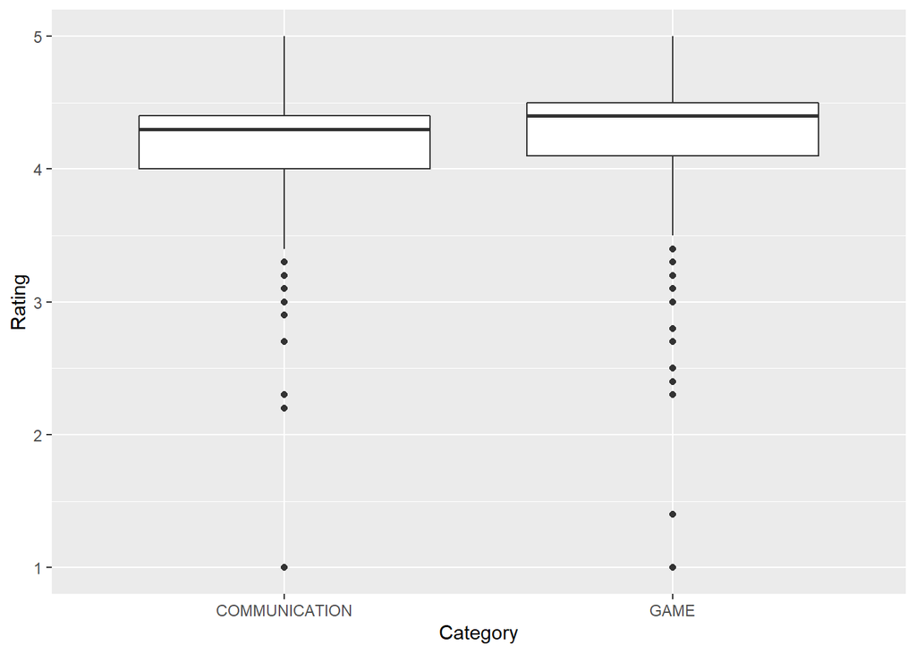

```r
read_csv("data/googleplaystore.csv") %>%
  filter(Category == "GAME" | Category == "COMMUNICATION") %>%
  select(Category, Rating) %>%  ggplot( mapping = aes(Category,Rating))+geom_boxplot()
```